```python
import pandas as pd
import numpy as np
import matplotlib.pyplot as plt
import seaborn as sns

plt.style.use('seaborn-white')
plt.rc('figure', dpi=100, figsize=(7, 5))
plt.rc('font', size=12)
```

# Lecture 22 – Modeling and `sklearn`

## DSC 80, Spring 2022

### Announcements

- Discussion 8 (regression) is today from 7-8:30PM.
- Project 4 has been released!
  - The checkpoint is due **tomorrow at 11:59PM**.
  - The full project is due **Thursday, May 26th at 11:59PM**.
  - Start early!
- Lab 8 is due on **Monday, May 23rd at 11:59PM**.

### Agenda

- Example: Restaurant tips 🧑‍🍳.
- `sklearn` overview.
- Transformers in `sklearn`.
- Models in `sklearn`.

## Example: Restaurant tips 🧑‍🍳

```python
tips = sns.load_dataset('tips')
tips
```

|  | total_bill | tip | sex | smoker | day | time | size |
| --- | --- | --- | --- | --- | --- | --- | --- |
| 0 | 16.99 | 1.01 | Female | No | Sun | Dinner | 2 |
| 1 | 10.34 | 1.66 | Male | No | Sun | Dinner | 3 |
| 2 | 21.01 | 3.50 | Male | No | Sun | Dinner | 3 |
| 3 | 23.68 | 3.31 | Male | No | Sun | Dinner | 2 |
| 4 | 24.59 | 3.61 | Female | No | Sun | Dinner | 4 |
| ... | ... | ... | ... | ... | ... | ... | ... |
| 239 | 29.03 | 5.92 | Male | No | Sat | Dinner | 3 |
| 240 | 27.18 | 2.00 | Female | Yes | Sat | Dinner | 2 |
| 241 | 22.67 | 2.00 | Male | Yes | Sat | Dinner | 2 |
| 242 | 17.82 | 1.75 | Male | No | Sat | Dinner | 2 |
| 243 | 18.78 | 3.00 | Female | No | Thur | Dinner | 2 |

244 rows × 7 columns

### Model #1: Constant

The first model we looked at last class used a constant tip **amount** prediction for every table.

$$\text{predicted tip} = h^*$$

If we use squared loss, the "best prediction is the mean of the observed tips.

```python
mean_tip = tips['tip'].mean()
mean_tip
```

```
2.9982786885245902
```

```python
def rmse(actual, pred):
    return np.sqrt(np.mean((actual - pred) ** 2))
```

```python
rmse(tips['tip'], mean_tip)
```

```
1.3807999538298958
```

```python
rmse_dict = {}
rmse_dict['constant, tip'] = rmse(tips['tip'], mean_tip)
```

### Model #2: Tip percentages instead of tips

The next model we created used a constant tip **percentage** prediction for every table.

$$\text{predicted tip percentage} = h^*$$

```python
tips = tips.assign(pct_tip=(tips['tip'] / tips['total_bill']))
tips.head()
```

|  | total_bill | tip | sex | smoker | day | time | size | pct_tip |
| --- | --- | --- | --- | --- | --- | --- | --- | --- |
| 0 | 16.99 | 1.01 | Female | No | Sun | Dinner | 2 | 0.059447 |
| 1 | 10.34 | 1.66 | Male | No | Sun | Dinner | 3 | 0.160542 |
| 2 | 21.01 | 3.50 | Male | No | Sun | Dinner | 3 | 0.166587 |
| 3 | 23.68 | 3.31 | Male | No | Sun | Dinner | 2 | 0.139780 |
| 4 | 24.59 | 3.61 | Female | No | Sun | Dinner | 4 | 0.146808 |

```python
mean_pct_tip = tips['pct_tip'].mean()
mean_pct_tip
```

```
0.16080258172250478
```

- Computing the RMSE of this model is a bit more nuanced.
- To fairly compare this model to the previous model, we must still be predicting `'tip'`, but above we have predicted `'pct_tip'`.
- **Key idea:** `'pct_tip'` is a **multiplier** that we apply to `'total_bill'` to get `'tip'`. That is:

$$\text{predicted tip} = \text{total bill} \cdot \text{mean pct-tip}$$

```python
tips['total_bill'] * mean_pct_tip
```

```
0      2.732036
1      1.662699
2      3.378462
3      3.807805
4      3.954135
         ...
239    4.668099
240    4.370614
241    3.645395
242    2.865502
243    3.019872
Name: total_bill, Length: 244, dtype: float64
```

```python
rmse_dict['constant, pct_tip'] = rmse(tips['tip'], tips['total_bill'] * mean_pct_tip)
rmse_dict
```

```
{'constant, tip': 1.3807999538298958, 'constant, pct_tip': 1.146820820140744}
```

### Constant tip vs. constant tip percentage

```python
mean_pct_tip
```

```
0.16080258172250478
```

```python
rmse_dict
```

```
{'constant, tip': 1.3807999538298958, 'constant, pct_tip': 1.146820820140744}
```

- A constant prediction of 16.08\% yields a lower RMSE than a constant prediction of \$3.
- However, both RMSEs are over \$1, which is relatively high compared to the mean tip amount of \\$3.
- How can we bring this RMSE down?

### Model #3: Linear model

- By choosing a loss function and minimizing empirical risk, we can find $w_0^*$ and $w_1^*$.
  - This process is **fitting** our model to the data.
  - $w_0^*$ and $w_1^*$ can be thought of as estimates of the true intercept and slope that exist in nature.
- In order to use a linear model, the data should have a linear association.

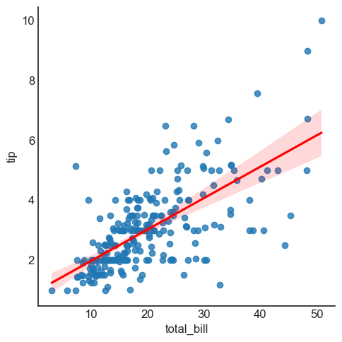

```python
sns.lmplot(data=tips, x='total_bill', y='tip', line_kws={'color': 'red'});
```

### Fitting a linear model

We'll learn more about `sklearn` today.

```python
from sklearn.linear_model import LinearRegression
```

```python
lr = LinearRegression()
lr.fit(X=tips[['total_bill']], y=tips['tip'])
```

```
LinearRegression()
```

```python
lr.intercept_, lr.coef_
```

```
(0.9202696135546735, array([0.10502452]))
```

Note that the above coefficients state that the "best way" (according to squared loss) to make tip predictions using a linear model is to assume people

- Tip ~\$0.92 up front, and
- ~10.5\% of every dollar thereafter.

```python
preds = lr.predict(X=tips[['total_bill']])
rmse_dict['simple linear model'] = rmse(tips['tip'], preds)
rmse_dict
```

```
{'constant, tip': 1.3807999538298958,
 'constant, pct_tip': 1.146820820140744,
 'simple linear model': 1.0178504025697377}
```

### Recap

- We built three models:
  - A constant model: $\text{predicted tip} = h^*$.
  - A linear model with no intercept: $\text{predicted tip} = w^* \cdot \text{total bill}$.
    - This was the model that involved tip percentage.
  - A linear model with an intercept: $\text{predicted tip} = w_0^* + w_1^* \cdot \text{total bill}$.
- As we added more features, our RMSEs decreased.
  - This was guaranteed to happen, since we were only looking at our training data.
- It is not clear that the final linear model is actually "better"; it doesn't seem to **reflect reality** better than the previous models.

### What's next?

There's a lot of information in `tips` that we didn't use – `'sex'`, `'smoker'`, `'day'`, and `'time'`, for example. How might we **encode** this information?

```python
tips.head()
```

|  | total_bill | tip | sex | smoker | day | time | size | pct_tip |
| --- | --- | --- | --- | --- | --- | --- | --- | --- |
| 0 | 16.99 | 1.01 | Female | No | Sun | Dinner | 2 | 0.059447 |
| 1 | 10.34 | 1.66 | Male | No | Sun | Dinner | 3 | 0.160542 |
| 2 | 21.01 | 3.50 | Male | No | Sun | Dinner | 3 | 0.166587 |
| 3 | 23.68 | 3.31 | Male | No | Sun | Dinner | 2 | 0.139780 |
| 4 | 24.59 | 3.61 | Female | No | Sun | Dinner | 4 | 0.146808 |

### One-hot encoding categorical variables

- Recall, we use **one-hot encoding** to transform **nominal categorical columns** into **binary columns**.
- Are all of the categorical columns in `tips` nominal?
  - Answer: `'day'` is ordinal, but we *can* still use one-hot encoding.

```python
tips.head()
```

|  | total_bill | tip | sex | smoker | day | time | size | pct_tip |
| --- | --- | --- | --- | --- | --- | --- | --- | --- |
| 0 | 16.99 | 1.01 | Female | No | Sun | Dinner | 2 | 0.059447 |
| 1 | 10.34 | 1.66 | Male | No | Sun | Dinner | 3 | 0.160542 |
| 2 | 21.01 | 3.50 | Male | No | Sun | Dinner | 3 | 0.166587 |
| 3 | 23.68 | 3.31 | Male | No | Sun | Dinner | 2 | 0.139780 |
| 4 | 24.59 | 3.61 | Female | No | Sun | Dinner | 4 | 0.146808 |

```python
categorical_cols = ['sex', 'smoker', 'day', 'time']
```

Let's one-hot encode the categorical columns in `tips`. Here's another way to do so manually:

```python
features = tips.copy().loc[:, ['total_bill', 'size']]
for c in categorical_cols:
    for val in tips[c].unique():
        features[f'{c}={val}'] = (tips[c] == val).astype(int)
```

```python
features.head()
```

|  | total_bill | size | sex=Female | sex=Male | smoker=No | smoker=Yes | day=Sun | day=Sat | day=Thur | day=Fri | time=Dinner | time=Lunch |
| --- | --- | --- | --- | --- | --- | --- | --- | --- | --- | --- | --- | --- |
| 0 | 16.99 | 2 | 1 | 0 | 1 | 0 | 1 | 0 | 0 | 0 | 1 | 0 |
| 1 | 10.34 | 3 | 0 | 1 | 1 | 0 | 1 | 0 | 0 | 0 | 1 | 0 |
| 2 | 21.01 | 3 | 0 | 1 | 1 | 0 | 1 | 0 | 0 | 0 | 1 | 0 |
| 3 | 23.68 | 2 | 0 | 1 | 1 | 0 | 1 | 0 | 0 | 0 | 1 | 0 |
| 4 | 24.59 | 4 | 1 | 0 | 1 | 0 | 1 | 0 | 0 | 0 | 1 | 0 |

Note that `features` has the same number of rows as `tips`; it just has more columns.

```python
tips.shape
```

```
(244, 8)
```

```python
features.shape
```

```
(244, 12)
```

Let's fit a linear model using all features in `features`!

```python
lr = LinearRegression()
lr.fit(X=features, y=tips['tip'])
```

```
LinearRegression()
```

```python
rmse_dict['all features'] = rmse(tips['tip'], lr.predict(X=features))
rmse_dict
```

```
{'constant, tip': 1.3807999538298958,
 'constant, pct_tip': 1.146820820140744,
 'simple linear model': 1.0178504025697377,
 'all features': 1.0051634500049156}
```

The RMSE of our latest model is the lowest of all linear models we've built so far (which is to be expected), **but not by much**. Perhaps these latest features weren't that useful.

We can visualize our latest model's predictions, too:

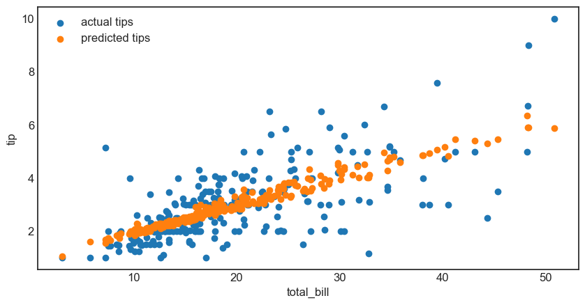

```python
preds = lr.predict(X=features)

plt.figure(figsize=(10, 5))
plt.scatter(tips['total_bill'], tips['tip'], label='actual tips')
plt.scatter(tips['total_bill'], preds, label='predicted tips')
plt.xlabel('total_bill')
plt.ylabel('tip')
plt.legend();
```

Why don't our model's predictions lie on a straight line? 🤔

### Aside: Periodic sales

- Recall, we can transform existing quantitative features into new quantitative features.
  - Often, we do this to make **linear relationships** more evident.
- Here, we have a dataset consisting of daily sales volumes from a (fictional) store.
- We'd like to **predict future sales**, given current trends.
  - What is the "shape" of the relationship between `'day'` and `'units sold'`?
    - Why is there periodicity ("peaks" and "valleys")?
  - How can we **transform** this relationship so that a linear model is suitable?

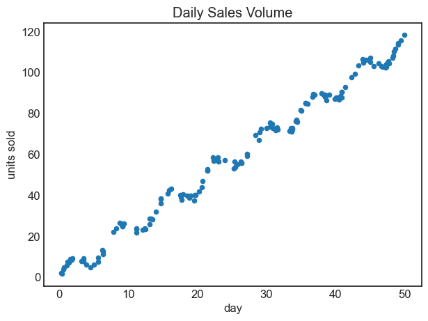

```python
sales = pd.read_csv('data/sinusoidal.csv').sort_values(by='day').reset_index(drop=True)
sales.plot(kind='scatter', x='day', y='units sold', title='Daily Sales Volume');
```

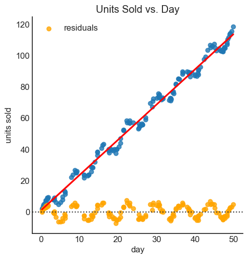

```python
sns.lmplot(data=sales, x='day', y='units sold', line_kws={'color': 'red'});
sns.residplot(data=sales, x='day', y='units sold', color='orange', label='residuals');
plt.title('Units Sold vs. Day')
plt.legend();
```

There is a **pattern** in the residual plot here, which is indicative that a linear model is not the best choice.

### Example: Periodic sales

- **Solution:** Transform either `'day'` or `'units_sold'` so that the resulting relationship between the two variables is roughly linear.
- Observation: It appears that sales are **sinusoidal**.
  - The "peaks" are spaced out by 7 days (1 week), so the period of the sinusoid is 7.
  - The height difference between a peak and a valley is approximately 10, so the amplitude of the sinusoid is $\frac{10}{2} = 5$.
  - Sales seem to be made up of a linear growth term and a sinusoidal term.
- As such, we can **transform `'day'`** using the feature function:

$$ \phi(x) = x + 5\sin\left(\frac{2\pi}{7} \cdot x\right) $$

```python
def transform_day(day):
    return day +  5 * np.sin(2 * np.pi * day / 7)
```

```python
sales['day_transformed'] = transform_day(sales['day'])
```

Let's draw two scatter plots:

- `'day_transformed'` vs. `'day'`.
- `'units sold'` vs. `'day'`.

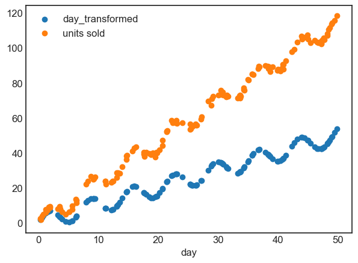

```python
plt.scatter(sales['day'], sales['day_transformed'], label='day_transformed')
plt.scatter(sales['day'], sales['units sold'], label='units sold')
plt.xlabel('day')
plt.legend();
```

While neither the orange scatter plot nor the blue scatter plot look linear, the relationship between the $y$-values in the two scatter plots *is* roughly linear!

Our new linear model will use `'day_transformed'` as the $x$ and `'units sold'` as the $y$.

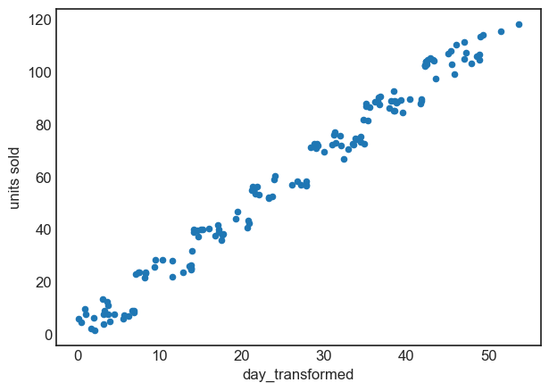

```python
sales.plot(kind='scatter', x='day_transformed', y='units sold');
```

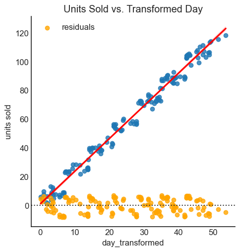

```python
sns.lmplot(data=sales, x='day_transformed', y='units sold', line_kws={'color': 'red'})
sns.residplot(data=sales, x='day_transformed', y='units sold', color='orange', label='residuals')
plt.title('Units Sold vs. Transformed Day')
plt.legend();
```

Now, the residual plot seems random, which is ideal!

## `sklearn` overview

### The steps of the modeling pipeline

[figure not shown]

1. Create features to best reflect the "meaning" behind data.
2. Choose a model that is appropriate to capture the relationships between features and the response.
3. Select a loss function and fit the model (i.e., determine $w^*$).
4. Evaluate the model (e.g. using RMSE).

### Features and models using `sklearn`

[figure not shown]

- Scikit-learn (`sklearn`) implements many common steps in the feature and model creation pipeline.
  - It is **widely** used throughout [industry](https://scikit-learn.org/stable/testimonials/testimonials.html#:~:text=It%20is%20very%20widely%20used,very%20approachable%20and%20very%20powerful.) and academia.
- It interfaces with `numpy` arrays, and to an extent, `pandas` DataFrames.
- Huge benefit: the [documentation online](https://scikit-learn.org/stable/modules/classes.html) is **excellent**.

### `preprocessing` and `linear_models`

For the **feature creation** step of the modeling pipeline, we will use `sklearn`'s [`preprocessing`](https://scikit-learn.org/stable/modules/classes.html#module-sklearn.preprocessing) module.

[figure not shown]

For the **model creation** step of the modeling pipeline, we will use `sklearn`'s [`linear_model`](https://scikit-learn.org/stable/modules/classes.html#module-sklearn.linear_model) module.

[figure not shown]

## Transformers in `sklearn`

### Transformer classes

- **Transformers** take in "raw" data and output "processed" data. They are used for **creating features**.
  - The input should be a multi-dimensional `numpy` array.
    - Inputs can be DataFrames, but `sklearn` only looks at the values (i.e. it calls `to_numpy()` on input DataFrames).
  - The output is a `numpy` array (never a DataFrame or Series).
- Transformers, like most relevant features of `sklearn`, are **classes**, not functions, meaning you need to instantiate them and call their methods.

### Example transformer: `Binarizer`

The `Binarizer` transformer allows us to map a quantitative sequence to a sequence of 1s and 0s, depending on whether values are above or below a threshold.

| Property | Example | Description |
| --- | --- | --- |
| Initialize with parameters | `binar = Binarizer(thresh)` | set x=1 if x > thresh, else 0 |
| Transform data in a dataset | `feat = binar.transform(data)` | Binarize all columns in `data` |

First, we need to import the relevant class from `sklearn.preprocessing`. (Tip: import just the relevant classes you need from `sklearn`.)

```python
from sklearn.preprocessing import Binarizer
```

Let's try binarizing `'total_bill'`. We'll say a "large" bill is one that is over \$20.

```python
tips = sns.load_dataset('tips') # To remove the columns we "engineered" before
tips['total_bill'].head()
```

```
0    16.99
1    10.34
2    21.01
3    23.68
4    24.59
Name: total_bill, dtype: float64
```

First, we initialize a `Binarizer` object with the threshold we want.

```python
bi = Binarizer(threshold=20)
```

Then, we call `bi`'s `transform` method and pass it the data we'd like to transform. Note that its input and output are both 2D.

```python
transformed_bills = bi.transform(tips[['total_bill']]) # Must pass transform a 2D array/DataFrame
transformed_bills[:5]
```

```
array([[0.],
       [0.],
       [1.],
       [1.],
       [1.]])
```

Cool! We can verify that it worked correctly:

```python
((tips['total_bill'] > 20).astype(int) == transformed_bills.flatten()).all()
```

```
True
```

### Example transformer: `StdScaler`

- `StdScaler` **standardizes** data using the mean and standard deviation of the data.

$$z_i = \frac{x_i - \bar{x}}{\sigma_x}$$

- Unlike `Binarizer`, `StdScaler` **requires some knowledge (mean and SD) of the dataset before transforming**.
- As such, we need to **`fit`** an `StdScaler` transformer before we can use the `transform` method.
- Typical usage: fit transformer on a sample; use that fit transformer to transform future data.

| Property | Example | Description |
| --- | --- | --- |
| Initialize with parameters | `stdscaler = StandardScaler()` | z-scale the data (no parameters) |
| Fit the transformer | `stdscaler.fit(data)` | compute the mean and SD of `data` |
| Transform data in a dataset | `feat = stdscaler.transform(newdata)` | z-scale `newdata` with mean and SD of `data` |

It only makes sense to standardize the already-quantitative columns of `tips`, so let's select just those.

```python
tips_quant = tips[['total_bill', 'tip', 'size']]
tips_quant.head()
```

|  | total_bill | tip | size |
| --- | --- | --- | --- |
| 0 | 16.99 | 1.01 | 2 |
| 1 | 10.34 | 1.66 | 3 |
| 2 | 21.01 | 3.50 | 3 |
| 3 | 23.68 | 3.31 | 2 |
| 4 | 24.59 | 3.61 | 4 |

Let's initialize a `StandardScaler` object.

```python
from sklearn.preprocessing import StandardScaler
```

```python
stdscaler = StandardScaler()
```

Note that the following **does not work!** The error message is very helpful.

```python
stdscaler.transform(tips_quant)
```

```
---------------------------------------------------------------------------
NotFittedError                            Traceback (most recent call last)
/var/folders/pd/w73mdrsj2836_7gp0brr2q7r0000gn/T/ipykernel_14076/3962348888.py in <module>
----> 1 stdscaler.transform(tips_quant)

~/opt/anaconda3/lib/python3.9/site-packages/sklearn/preprocessing/_data.py in transform(self, X, copy)
    878             Transformed array.
    879         """
--> 880         check_is_fitted(self)
    881
    882         copy = copy if copy is not None else self.copy

~/opt/anaconda3/lib/python3.9/site-packages/sklearn/utils/validation.py in inner_f(*args, **kwargs)
     61             extra_args = len(args) - len(all_args)
     62             if extra_args <= 0:
---> 63                 return f(*args, **kwargs)
     64
     65             # extra_args > 0

~/opt/anaconda3/lib/python3.9/site-packages/sklearn/utils/validation.py in check_is_fitted(estimator, attributes, msg, all_or_any)
   1096
   1097     if not attrs:
-> 1098         raise NotFittedError(msg % {'name': type(estimator).__name__})
   1099
   1100

NotFittedError: This StandardScaler instance is not fitted yet. Call 'fit' with appropriate arguments before using this estimator.
```

Instead, we need to first call the `fit` method on `stdscaler`.

```python
stdscaler.fit(tips_quant)
```

```
StandardScaler()
```

Now, `transform` will work.

```python
# First column is 'total_bill', second column is 'tip', third column is 'size'
tips_quant_z = stdscaler.transform(tips_quant)
tips_quant_z[:5]
```

```
array([[-0.31471131, -1.43994695, -0.60019263],
       [-1.06323531, -0.96920534,  0.45338292],
       [ 0.1377799 ,  0.36335554,  0.45338292],
       [ 0.4383151 ,  0.22575414, -0.60019263],
       [ 0.5407447 ,  0.4430195 ,  1.50695847]])
```

We can also access the mean and variance `stdscaler` computed for each column:

```python
stdscaler.mean_
```

```
array([19.78594262,  2.99827869,  2.56967213])
```

```python
stdscaler.var_
```

```
array([78.92813149,  1.90660851,  0.9008835 ])
```

Note that we can call `transform` on DataFrames other than `tips_quant`:

```python
stdscaler.transform(tips_quant.head(5))
```

```
array([[-0.31471131, -1.43994695, -0.60019263],
       [-1.06323531, -0.96920534,  0.45338292],
       [ 0.1377799 ,  0.36335554,  0.45338292],
       [ 0.4383151 ,  0.22575414, -0.60019263],
       [ 0.5407447 ,  0.4430195 ,  1.50695847]])
```

### Example transformer: `OneHotEncoder`

Let's keep just the categorical columns in `tips`.

```python
tips_cat = tips[['sex', 'smoker', 'day', 'time']]
tips_cat.head()
```

|  | sex | smoker | day | time |
| --- | --- | --- | --- | --- |
| 0 | Female | No | Sun | Dinner |
| 1 | Male | No | Sun | Dinner |
| 2 | Male | No | Sun | Dinner |
| 3 | Male | No | Sun | Dinner |
| 4 | Female | No | Sun | Dinner |

Like `StdScaler`, we will need to `fit` our `OneHotEncoder` transformer before it can transform anything.

```python
from sklearn.preprocessing import OneHotEncoder
```

```python
ohe = OneHotEncoder()
ohe.fit(tips_cat)
```

```
OneHotEncoder()
```

We can look at the unique values (i.e. categories) in each column by using the `categories_` attribute:

```python
ohe.categories_
```

```
[array(['Female', 'Male'], dtype=object),
 array(['No', 'Yes'], dtype=object),
 array(['Fri', 'Sat', 'Sun', 'Thur'], dtype=object),
 array(['Dinner', 'Lunch'], dtype=object)]
```

```python
ohe_features = ohe.transform(tips_cat)
ohe_features
```

```
<244x10 sparse matrix of type '<class 'numpy.float64'>'
	with 976 stored elements in Compressed Sparse Row format>
```

Since the resulting matrix is **sparse** – most of its elements are 0 – `sklearn` uses a more efficient representation than a regular `numpy` array. That's no issue, though:

```python
ohe_features.toarray()
```

```
array([[1., 0., 1., ..., 0., 1., 0.],
       [0., 1., 1., ..., 0., 1., 0.],
       [0., 1., 1., ..., 0., 1., 0.],
       ...,
       [0., 1., 0., ..., 0., 1., 0.],
       [0., 1., 1., ..., 0., 1., 0.],
       [1., 0., 1., ..., 1., 1., 0.]])
```

Notice that the column names from `tips_cat` are no longer stored anywhere (remember, `fit` converts the input to a `numpy` array before proceeding).

We can use the `get_feature_names` method on `ohe` to access the names of the one-hot-encoded columns, though:

```python
ohe.get_feature_names() # x0, x1, x2, and x3 correspond to column names in tips_cat
```

```
array(['x0_Female', 'x0_Male', 'x1_No', 'x1_Yes', 'x2_Fri', 'x2_Sat',
       'x2_Sun', 'x2_Thur', 'x3_Dinner', 'x3_Lunch'], dtype=object)
```

`ohe` also has an `inverse_transform` method, which takes a one-hot-encoded matrix and returns a categorical matrix.

```python
ohe.inverse_transform(ohe_features[:10])
```

```
array([['Female', 'No', 'Sun', 'Dinner'],
       ['Male', 'No', 'Sun', 'Dinner'],
       ['Male', 'No', 'Sun', 'Dinner'],
       ['Male', 'No', 'Sun', 'Dinner'],
       ['Female', 'No', 'Sun', 'Dinner'],
       ['Male', 'No', 'Sun', 'Dinner'],
       ['Male', 'No', 'Sun', 'Dinner'],
       ['Male', 'No', 'Sun', 'Dinner'],
       ['Male', 'No', 'Sun', 'Dinner'],
       ['Male', 'No', 'Sun', 'Dinner']], dtype=object)
```

## Models in `sklearn`

### Model classes

- `sklearn` model classes (called "estimators") behave like transformers, in that we need to instantiate and `fit` them.
- The difference is that we also need to specify what our "response" or "target" variable is, i.e. what we are trying to predict.
  - Calling `fit` is the same as "training our model".
- There are several models in the [`linear_model`](https://scikit-learn.org/stable/modules/classes.html#module-sklearn.linear_model) package; we will start with `LinearRegression`.

### The `LinearRegression` class

We've seen this a few times in lecture already, but never formally.

```python
from sklearn.linear_model import LinearRegression
```

**Important:** From [the documentation](https://scikit-learn.org/stable/modules/generated/sklearn.linear_model.LinearRegression.html#sklearn.linear_model.LinearRegression), we have

> LinearRegression fits a linear model with coefficients w = (w1, …, wp) to minimize the residual sum of squares between the observed targets in the dataset, and the targets predicted by the linear approximation.

In other words, `LinearRegression` minimizes mean squared error by default.

Additionally, by default the `fit_intercept` argument is set to `True`.

```python
LinearRegression?
```

### Example: Predicting `'tip'` from `'total_bill'` and `'size'`

```python
tips.head()
```

|  | total_bill | tip | sex | smoker | day | time | size |
| --- | --- | --- | --- | --- | --- | --- | --- |
| 0 | 16.99 | 1.01 | Female | No | Sun | Dinner | 2 |
| 1 | 10.34 | 1.66 | Male | No | Sun | Dinner | 3 |
| 2 | 21.01 | 3.50 | Male | No | Sun | Dinner | 3 |
| 3 | 23.68 | 3.31 | Male | No | Sun | Dinner | 2 |
| 4 | 24.59 | 3.61 | Female | No | Sun | Dinner | 4 |

First, we instantiate and fit. By calling `fit`, we are saying "minimize mean squared error and find $w^*$".

```python
lr = LinearRegression()

# Note that there are two arguments to fit – X and y!
# (It is not necessary to write X= and y=)
lr.fit(X=tips[['total_bill', 'size']], y=tips['tip'])
```

```
LinearRegression()
```

After fitting, the `predict` method is available. Note that the argument to `predict` can be any 2D array with two columns.

```python
# Predicted tip from a table of 3 that spends $25
lr.predict([[25, 3]])
```

```
array([3.56457154])
```

```python
# Predicted tip from a table of 14 that spends $1000 – probably not accurate!
lr.predict([[1000, 14]])
```

```
array([96.07865069])
```

We can access the intercepts and slopes individually. This model is of the form

$$\text{predicted tip} = w_0^* + w_1^* \cdot \text{total bill} + w_2^* \cdot \text{table size}$$

so we should expect three parameters total.

```python
lr.intercept_
```

```
0.6689447408125031
```

```python
lr.coef_
```

```
array([0.09271334, 0.19259779])
```

If we want to compute the RMSE of our model, we need to find its predictions on every row in the training data (`tips`).

```python
all_preds = lr.predict(tips[['total_bill', 'size']])
```

```python
np.sqrt(np.mean((all_preds - tips['tip']) ** 2))
```

```
1.0072561271146618
```

It turns out that fit `LinearRegression` objects also have a `score` method:

```python
lr.score(tips[['total_bill', 'size']], tips['tip'])
```

```
0.46786930879612587
```

That doesn't look like the RMSE... what is it? 🤔

### Aside: $R^2$

- $R^2$, or the **coefficient of determination**, is a measure of the **quality of a linear fit**.
- There are a few equivalent ways of computing it, assuming your model has an intercept term:

$$R^2 = \frac{\text{var}(\text{predicted $y$ values})}{\text{var}(\text{actual $y$ values})}$$$$R^2 = \left[ \text{correlation}(\text{predicted $y$ values}, \text{actual $y$ values}) \right]^2$$

- In the simple linear regression case, it is the square of the correlation coefficient, $r$.
- **Key idea:** $R^2$ ranges from 0 to 1. **The closer it is to 1, the better the linear fit is.**
- Interpretation: $R^2$ is the **proportion of variance in $y$ that the linear model explains**.

### Calculating $R^2$

Recall, `all_preds` contains the predicted `'tip'` for every data point in `tips`.

```python
tips.head()
```

|  | total_bill | tip | sex | smoker | day | time | size |
| --- | --- | --- | --- | --- | --- | --- | --- |
| 0 | 16.99 | 1.01 | Female | No | Sun | Dinner | 2 |
| 1 | 10.34 | 1.66 | Male | No | Sun | Dinner | 3 |
| 2 | 21.01 | 3.50 | Male | No | Sun | Dinner | 3 |
| 3 | 23.68 | 3.31 | Male | No | Sun | Dinner | 2 |
| 4 | 24.59 | 3.61 | Female | No | Sun | Dinner | 4 |

```python
all_preds[:5]
```

```
array([2.62933992, 2.20539403, 3.19464533, 3.24959215, 3.71915687])
```

**Method 1: $R^2 = \frac{\text{var}(\text{predicted $y$ values})}{\text{var}(\text{actual $y$ values})}$**

```python
np.var(all_preds) / np.var(tips['tip'])
```

```
0.4678693087961248
```

**Method 2:** $R^2 = \left[ \text{correlation}(\text{predicted $y$ values}, \text{actual $y$ values}) \right]^2$

Note: By correlation here, we are referring to $r$.

```python
(np.corrcoef(all_preds, tips['tip'])) ** 2
```

```
array([[1.        , 0.46786931],
       [0.46786931, 1.        ]])
```

**Method 3:** `lr.score`

```python
lr.score(tips[['total_bill', 'size']], tips['tip'])
```

```
0.46786930879612587
```

All three methods provide the same result!

### `LinearRegression` summary

| Property | Example | Description |
| --- | --- | --- |
| Initialize model parameters | `lr = LinearRegression()` | Create (empty) linear regression model |
| Fit the model to the data | `lr.fit(data, responses)` | Determines regression coefficients |
| Use model for prediction | `lr.predict(newdata)` | Use regression line make predictions |
| Evaluate the model | `lr.score(data, responses)` | Calculate the $R^2$ of the LR model |
| Access model attributes | `lr.coef_` | Access the regression coefficients |

*Note:* Once `fit`, estimators like `LinearRegression` are just transformers (`predict` <-> `transform`).

## Summary, next time

### Summary

- Quantitative feature transformations allow us to use linear models to model non-linear data.
- Transformers in `sklearn` are used for **feature engineering**, while estimators in `sklearn` are used for **models**.
- A common pattern:
  - Instantiate.
  - `fit`.
  - `transform` / `predict`.
- We like linear models with **low RMSE** and **high $R^2$**!
- **Next time:** Combining transformers and estimators in a single **pipeline**.